# Project: Investigate the TMDb Dataset

### Movies that release in which month are of higher budget, make higher revenue and profit?

> For this analysis we need to make a new property for the dataframe we used. Months. Once we get months, we group data by months and furthur analyse them, over allt he month.

> We take the average budget of movies based on the month they were released. We find that most movies of higher budget come during the month of june. And also december. Considering this is the holiday seasons, it might also factor in for higher revenue.

> Similarly we check for budget and profit which is revenue-budget (approximately)

```python
def find_month(date):
    return date.month
```

```python
movies_db['profit']=movies_db['revenue']-movies_db['budget']
```

```python
# find month of release
movies_db['release_month']=movies_db['release_date'].apply(find_month)
```

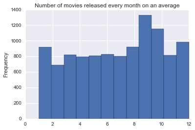

```python
# Check the number of movies released each month
movies_db['release_month'].plot(kind='hist',bins=12, title='Number of movies released every month on an average')
```

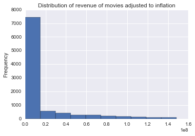

```python
# Let's check the distribution of revenue of movies.
movies_db['revenue_adj'][movies_db['revenue_adj']<movies_db['revenue_adj'].quantile(.9)].plot(kind='hist',bins=10, title='Distribution of revenue of movies adjusted to inflation')
```

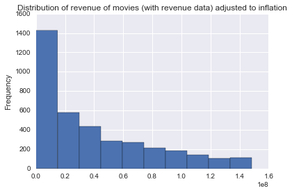

```python
# most revenues are 0 so we need to excluse those values
movies_db['revenue_adj'][(movies_db['revenue_adj']<movies_db['revenue_adj'].quantile(.9)) & (movies_db['revenue_adj']!=0)].plot(kind='hist',bins=10, title='Distribution of revenue of movies (with revenue data) adjusted to inflation')
```

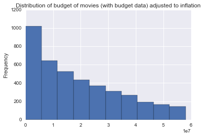

```python
movies_db['budget_adj'][(movies_db['budget_adj']<movies_db['budget_adj'].quantile(.9)) & (movies_db['budget_adj']!=0)].plot(kind='hist',bins=10, title='Distribution of budget of movies (with budget data) adjusted to inflation')
```

```python
# Group by release month
data_by_month = movies_db.groupby('release_month')
```

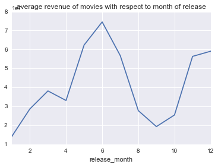

```python
data_by_month['revenue'].mean().plot(title='average revenue of movies with respect to month of release')
```

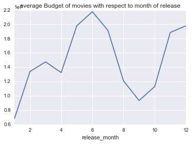

```python
data_by_month['budget'].mean().plot(title='average Budget of movies with respect to month of release')
```

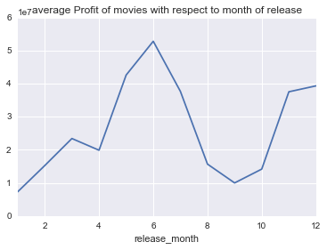

```python
data_by_month['profit'].mean().plot(title='average Profit of movies with respect to month of release')
```

### Genre and Revenue over time

> We see which genre have gained more popularity over time. Handling the data for this was a bit of a chellenge. So I created a dataset based on individual genres throught he years, as we cannot consider them as a group as given in the data.

> For this we first gather all possible genre in a list.

```python
# Collecting all genre in a set
# Set makes sure they don't repeat, without you explicitely checking if the new genre you add already exists or not
all_genre = set()

for g_list in movies_db['genres']:
    all_genre.update(g_list)
all_genre = list(all_genre)
```

```python
print all_genre
```

```
['Mystery', 'Romance', 'History', 'Family', 'Fantasy', 'Horror', 'Crime', 'Drama', 'Science Fiction', 'Animation', 'Music', 'Adventure', 'Foreign', 'Action', 'TV Movie', 'Comedy', 'Documentary', 'War', 'Thriller', 'Western']
```

```python
movies_db['genres'][0]
```

```
['Action', 'Adventure', 'Science Fiction', 'Thriller']
```

### Common Genres

> Some genres are hardly used in any movies and some more popularly used. So we consider the one more popularly used in movies to make sure that we have enough data to analyse effectively. We take the genre with more number of movies.

```python
# Which genre is the most common.
genre_count = defaultdict(list)
```

```python
# movies_db['revenue_adj'] has the revenues of all movies per genre.
# length of that of that would give the number of movies per genre.

for i,v in enumerate(movies_db['genres']):
    for genre in v:
        genre_count[genre].append(movies_db['revenue_adj'][i])
```

```python
# Average of each of those length would give the average number of movies each genre has.
all_genre_count = []
for k,v in genre_count.iteritems():
    all_genre_count.append(len(v))
genre_count_avg = sum(all_genre_count)/len(all_genre_count)
```

```python
print genre_count_avg
```

```
1348
```

```python
# These are the list of popular genres.
popular_genre = []
```

```python
for k,v in genre_count.iteritems():
    if len(v) > genre_count_avg:
        popular_genre.append(k)
```

```python
popular_genre
```

```
['Romance',
 'Horror',
 'Crime',
 'Drama',
 'Adventure',
 'Action',
 'Comedy',
 'Thriller']
```

### Getting the data in the right data structure for analysis.

> We have already investigated the visualisation of distribution of years, revenue and budget for single variate analysis. So we go to the multivariate analysis directly with respect to genre.
> 1. Put it in a data structure in the format {genre:{year:[revenues]}}
> 2. Turn it into a dataframe of collection of all genre and year combination and average revenue.

> This is done in the code below

```python
genre_dict=defaultdict(dict)
```

```python
for gen in popular_genre:
    for genre_loc,genre in movies_db['genres'].iteritems():
        if gen in genre:
#             Ignore all 0 values
            if not movies_db['revenue'][genre_loc] == 0:
                if movies_db['release_year'][genre_loc] not in genre_dict[gen]:
                    genre_dict[gen][movies_db['release_year'][genre_loc]]=[movies_db['revenue'][genre_loc]]
                else:
                    genre_dict[gen][movies_db['release_year'][genre_loc]].append(movies_db['revenue'][genre_loc])
```

```python
genre_dict['Action'][1960]
```

```
[4905000, 60000000]
```

```python
# Create a dataframe out of the dict. step 1: create empty dataframe
popular_genre_avg_revenue_db = pd.DataFrame(columns=popular_genre,index=range(movies_db['release_year'].min(),movies_db['release_year'].max()+1))
```

```python
# Add elements into the dataframe from genre_dict
for genre_key,genre_value in genre_dict.iteritems():
    for year_key,year_value in genre_value.iteritems():
        popular_genre_avg_revenue_db[genre_key][year_key]=sum(year_value)/len(year_value)
```

```python
popular_genre_avg_revenue_db_indexout=popular_genre_avg_revenue_db.reset_index()
```

```python
popular_genre_avg_revenue_db_indexout_past_1980=popular_genre_avg_revenue_db_indexout[popular_genre_avg_revenue_db_indexout['index']>1980]
```

### Visualisation of genre and revenue over the years.

> We see a great increase in revenue in few genres. But We also see a lot of noise. So we select a few genres that show growth in the second visualisation.

```python
print popular_genre
```

```
['Romance', 'Horror', 'Crime', 'Drama', 'Adventure', 'Action', 'Comedy', 'Thriller']
```

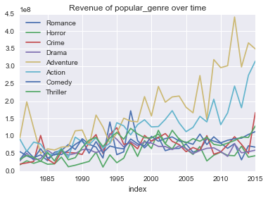

```python
# Build visualization
popular_genre_avg_revenue_db_indexout_past_1980.plot(x='index', y=popular_genre, kind="line", title='Revenue of popular_genre over time')
```

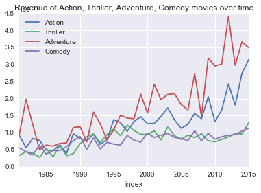

```python
popular_genre_avg_revenue_db_indexout_past_1980.plot(x='index', y=['Action','Thriller','Adventure','Comedy'], kind="line", title="Revenue of Action, Thriller, Adventure, Comedy movies over time")
```

## Conclusions

#### Runtime vs year of release

> There might be a possibility that movies are getting shorter over the years. Especially lately in the last 15 years. The data is noisy pre-90s and is mostly constant. So we focused on the post 90s era. We see a steady pattern of how movies are getting shorter. It might be a good thing to see well packed movies in a shorter time.

#### Preference of month of release

> There is a clear pattern on when movies are released. This doesn't imply causation that movies make more money during summers and december. There could be many factors affecting this. But the difference in revenue is significant.

#### Genre Preference

All of these show correation between various fields. Runtime over the years has shown a drop. But this doesn't show any statistical significance. Similarly month of release doesn't cause movies to generate high revenue, and making a movie of a particular genre wont cause a movie to get high revenue.